## Calculate and use historical volatility calculated on log returns in the last year. Ignore any dividends.

We use stock 'AAPL' as a example

```python
import os
import datetime
import pandas as pd
import numpy as np
import matplotlib.pyplot as plt
from scipy.stats import norm
from pandas_datareader import data as pdr

# Getdata from Yahoo Finance
start = datetime.datetime(2018, 12, 3)
end = datetime.datetime(2019, 12, 2)
data = pdr.get_data_yahoo('AAPL', start=start, end=end)
S = data[['Adj Close']]

def Volatility(S):
    re = np.log(S/S.shift(1)).dropna()
    return re.std()*np.sqrt(252)
```

```python
#Calculate volatility
sigma = Volatility(S).values[0]
```

## Choose the strike so that the price never "touched" during the last year: call strike slightly above the maximum price during the last year, and put strike slightly below the minimum during the last year.

```python
S.min()
```

```
Adj Close    140.08522
dtype: float64
```

So we choose put strike = 140

## Calculate the option price using your previously deducted formula. Compare the price with vanilla digital with the same strike and expiration.

We use LIBOR rate 0.02 as interest rate in the formula

```python
def onetouch_put(S,E,T,t,r,sigma):
    d1 = (np.log(S/E)+(r+0.5*sigma**2)*(T-t))/(sigma*np.sqrt(T-t))
    d2 = (np.log(S/E)-(r+0.5*sigma**2)*(T-t))/(sigma*np.sqrt(T-t))
    Price = (S/E)*norm.cdf(-d1)+(S/E)**(-2*r/sigma**2)*norm.cdf(-d2)
    delta = 1/E*norm.cdf(-d1)-S/E*(1/(S*sigma*np.sqrt(T-t)))*norm.pdf(-d1)-(2*r/sigma**2)*(1/E)**(-2*r/sigma**2)*S**(-(2*r/sigma**2)-1)*norm.cdf(-d2)-(S/E)**(-2*r/sigma**2)*norm.pdf(-d2)*(1/(S*sigma*np.sqrt(T-t)))
    return Price,delta

def vanilla_digital_put(S,E,T,t,r,sigma):
    h = (np.log(S/E)+(r-0.5*sigma**2)*(T-t))/(sigma*np.sqrt(T-t))
    Price = np.exp(-r*(T-t))*norm.cdf(-h)
    return Price
```

```python
#Initialize parameters
Stock = S.iloc[:,0].values
E = 140
t = np.linspace(0,1,252)
T = np.ones(252)*2
r = 0.02

#Calculate options prices and delta
OneTouch_Price,delta = onetouch_put(Stock,E,T,t,r,sigma)
Vanilla_Digital_Price = vanilla_digital_put(Stock,E,T,t,r,sigma)
```

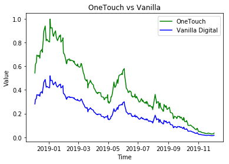

```python
x = S.index
y1 = OneTouch_Price
y2 = Vanilla_Digital_Price

#Plot the value of two options
plt.title('OneTouch vs Vanilla')
plt.plot(x, y1, color='g', label='OneTouch')
plt.plot(x, y2, 'b', label='Vanilla Digital')
plt.legend()
plt.xlabel('Time')
plt.ylabel('Value')
plt.show()
```

## Plot the price vs moneyness ln(S/E) and check the model with MonteCarlo Simulation

We use the parameters above, except stock prices.

For MonteCarlo test, we simulate 10,000 times for each stock price and calucalate average errors.

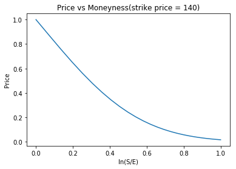

```python
s_simu = np.arange(140,E*np.exp(1),10)
moneyness = np.log(s_simu/E)
y_anal = onetouch_put(s_simu,E,2,0,r,sigma)[0]

plt.title('Price vs Moneyness(strike price = 140)')
plt.plot(moneyness, y_anal)
plt.xlabel('ln(S/E)')
plt.ylabel('Price')
plt.show()
```

```python
def simulation(s0,K,r,sigma,T,n):
    c = 0
    def MonteCarlo():
        s = []
        s.append(s0)
        for i in range(1,int(252*T)):
            s.append(s[i-1]*np.exp((r-0.5*(sigma**2))*(1/252)+sigma*np.sqrt(1/252)*np.random.randn()))
            if s[i]<=K:
                return np.exp(-r*i/252)
        return 0
    for i in range(n):
        c+=MonteCarlo()
    return c/n

y_simu=[] #the value of option by MC
for i in range(len(s_simu)):
    y_simu.append(simulation(s_simu[i],E,r,sigma,2,10000))


error = np.mean((y_anal- y_simu)/y_simu)
error
```

```
0.05220098309458182
```

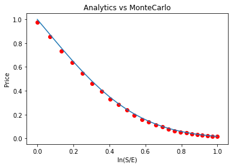

```python
plt.title('Analytics vs MonteCarlo')
plt.scatter(moneyness, y_simu,c = 'r',marker = 'o')
plt.plot(moneyness, y_anal)
plt.xlabel('ln(S/E)')
plt.ylabel('Price')
plt.show()
```

## Construct the following portfolio: 1000 contracts of the your specified option and short position in stock (hedge) with position=-1000*Delta of the option, each day the short position will be different.

```python
#Construct hedging matrix
hedge_matrix = S
hedge_matrix['option']=OneTouch_Price
hedge_matrix['delta']=delta

hedge_matrix['Pnl'] = 1000*(hedge_matrix['option']-hedge_matrix['option'].shift(1)-hedge_matrix['delta'].shift(1)*(hedge_matrix['Adj Close']-hedge_matrix['Adj Close'].shift(1)))
```

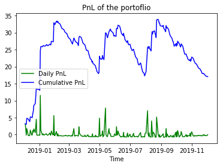

```python
#plot daily and cumulative PnL
plt.title('PnL of the portoflio')
plt.plot(x, hedge_matrix['Pnl'], color='g', label='Daily PnL')
plt.plot(x, hedge_matrix['Pnl'].cumsum(), 'b', label='Cumulative PnL')
plt.legend()
plt.xlabel('Time')
plt.show()
```